# HW 3

In this homework, KNN Classification and Logistic Regression for different data sets are applied.

## Part1

I have read the data from files, and plot them in 3D.

```r
filename='UWAVE_TRAIN'
Files=list.files(paste0("C:/Users/eda.yildiz/Downloads/",filename))

traindatax <- as.matrix(read.table(paste0("C:/Users/eda.yildiz/Downloads/",filename,"/",Files[1])))
traindatay <- as.matrix(read.table(paste0("C:/Users/eda.yildiz/Downloads/",filename,"/",Files[2])))
traindataz <- as.matrix(read.table(paste0("C:/Users/eda.yildiz/Downloads/",filename,"/",Files[3])))

trainclass=traindatax[,1] # takes -1 and 1

#drop first column
traindatax=traindatax[,2:ncol(traindatax)]
traindatay=traindatay[,2:ncol(traindatay)]
traindataz=traindataz[,2:ncol(traindataz)]
```

For each class an instance is chosen. You can see the graphs for each class example below. As it is mentioned in the Homework paper, Shapes that revealed from the instances are related with the gestures shown in the HW.

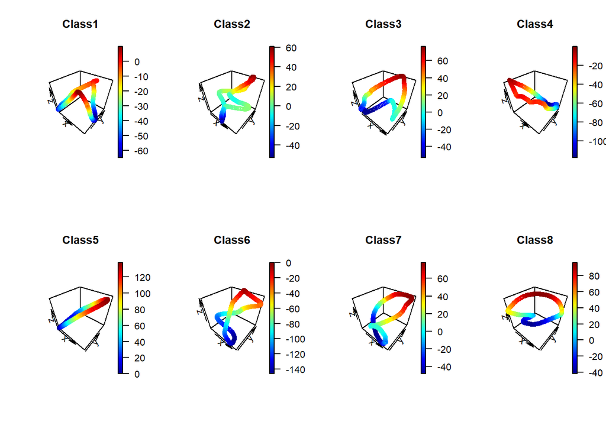

# Part1 - B

After combining the information of X, Y and Z coordinates colunmwise with the help of the cbind function to obtain a single vector for each gesture, I calculate similarities between time series for a eucledian and manhattan distance.

For each distance measure 10- fold cross validation is applied. The data i divided by 10 and each part is tested when other parts are taken as training data. This is done by using the function generateCVRuns. The parameter Stratified is set to be TRUE since the conservation of density for each class in the test and train data is important.

After obtaining 10fold data sets the following steps are applied:

-Similarity is calculated among test and train data sets -Trainig Points are ordered from the closest points to farthest point -For each k from 1 to 10 –The mode of the class information for the points up to k is calculated for each test point –The Class Information obtained is assigned to the the test points

## Part 1- C

As mentioned below k=4 is chosen for both Eucledian and Manhattan Distance.

```
##           Actual
## Prediction   1   2   3   4   5   6   7   8
##          1 431   1   0   6   3   4   0   0
##          2   0 449   0   0   0   0   0   0
##          3   0   0 417   0   7   6   1   0
##          4   2   0   0 370   1  14   0   2
##          5   0   0  17  58 420  29   0   1
##          6   4   0  15   9   2 396   0   0
##          7   0   2   5   0   0   0 446   0
##          8   0   0   0   7   0   0   0 457
```

```
## Time difference of 3.378513 mins
```

```
##           Actual
## Prediction   1   2   3   4   5   6   7   8
##          1 429   1   1   2   3   5   0   0
##          2   0 451   0   0   0   0   0   0
##          3   0   0 420   0   6   3   3   0
##          4   4   0   0 387   1  11   0   1
##          5   0   0  14  47 422  26   0   2
##          6   4   0  15   8   1 404   0   0
##          7   0   0   4   0   0   0 444   0
##          8   0   0   0   6   0   0   0 457
```

```
## Time difference of 3.017784 mins
```

## Part2 A

In this part we are supposed to train a logistic regression model on the training data using fused lasso penalties. I used penalized packae since LQA does not support my R version.

Firstly Model should learn the parameters of fused lasso through cross-validation on training data. In the penalized package cross-validation is already implemented in the function optL2.

I gave Lambda1 as 1 and find the optimum lambda2 value among 0 and 3. And the model choose to use Lambda as 3.

For the best value of Lambda I predict the test labels and calculate the accuracy. The two by two confusion matrix is as follows :

```
##           Actual
## Prediction  0  1
##          0 25  7
##          1 11 57
```

# Part 2 B

Coefficients of the logistic regression are as follows:

```
##          V2          V3          V4          V5          V6          V7
## -0.01239883 -0.01239883 -0.01239883 -0.01239883 -0.01239883 -0.13166967
##          V8          V9         V12         V13         V14         V15
## -0.13166967 -0.13166967  0.07506376  0.07506376  0.07506376  0.07506376
##         V16         V17         V18         V30         V31         V32
##  0.07506376  0.07506376  0.07506376 -0.17451294 -0.17451294 -0.17451294
##         V33         V34         V35         V36         V37         V41
## -0.17451294 -0.17451294 -0.17451294 -0.17451294 -0.17451294  0.12545419
##         V42         V43         V44         V45         V46         V47
##  0.12545419  0.12545419  0.12545419  0.12545419  0.12545419  0.12545419
##         V48         V49         V81         V82         V83         V84
##  0.12545419  0.12545419 -0.02285725 -0.02285725 -0.02285725 -0.02285725
##         V85         V86         V87         V88         V89         V90
## -0.02285725 -0.02285725 -0.02285725 -0.02285725 -0.02285725 -0.02285725
##         V96         V97
## -0.69391828 -0.69391828
```

# Part 2 C-D

If we take the difference between consecutive time series observations to transform the time series the confusion matrix will be as follows:

```
##               testclass
## TestResultDiff  0  1
##              0 26  5
##              1 10 59
```

As you can see the results are highly similar.There is a small difference between the classification counts.

The coefficients for the model of differences :

```
##  [1]  0.27225670  0.69735895 -0.37415972  0.00772233  0.47319496
##  [6]  0.54027405  0.54027405  0.54027405  0.54027405 -0.37555023
## [11] -0.37555023  0.72255261  0.77921690  0.77921690  0.77921690
## [16]  0.77921690  0.08835171 -0.47377261 -0.43853843 -0.43853843
```

As you notices in the second model we have much less number of coefficients but highly similar results to the first model.